# Lu,STAT479_midterm

### 2.2 Hyperparameter Tuning

Hyperparameter tuning will be performed with the RandomizedSearchCV tool from the sci-kit.learn library. I chose 6 parameters to tune:

- **Number of neurons**: number of neurons per layer
- **Number of hidden layers**: increasing the number of hidden layers will introduce complexity into the model, which can help with underfitting
- **Learning Rate**: the strength by which newly acquired information overrides old information. A smaller learning rate will allow the model move through more options but runs the risk of getting stuck at a local minima. A higher learning rate might lead to the model converging too fast.
- **Dropout**: dropping out nodes in between layers. The dropout rate refers to a randomly selected percent of the neurons being dropped in every iteration. This helps prevent overfitting by allowing the model to generalize on new data.
- **Batch Size**: the number of training samples to work through before the parameters are updated. Smaller batch sizes generally give more accurate predictions, but they are time and resource intensive. Large batch sizes give faster training times, but lower accuracy.
- **Epochs**: A single epoch is one complete pass of the training dataset through the algorithm. The model should be able to decrease loss and increase accuracy across epochs.

```python
from scikeras.wrappers import KerasClassifier
from sklearn.model_selection import RandomizedSearchCV

def build_model(num_layers=1, num_neurons=16, dropout_rate=0.5, learning_rate=0.01, batch_size=16, epochs=10):
    N, D = X_train.shape
    model = Sequential([
        Dense(num_neurons, activation = 'relu', input_shape=(D,)),
        Dense(num_neurons, activation = 'relu'),
        Dropout(rate = dropout_rate),
        Dense(1, activation = 'sigmoid')
        ])

    # Compile the model
    model.compile(optimizer=Adam(learning_rate = learning_rate), loss='binary_crossentropy', metrics=['accuracy'])
    return model

model = KerasClassifier(
                        build_fn=build_model,
                        num_layers=1,
                        num_neurons=16,
                        dropout_rate=0.5,
                        learning_rate=0.01,
                        batch_size=16,
                        epochs=10,
                        verbose=0)
```

```python
# Hyperparameter Tuning with Random Search
hyper_params = {
    'num_layers': [1, 2, 3, 4],
    'num_neurons': [16, 32, 64, 128],
    'dropout_rate': [0.5, 0.1, 0.01, 0.001],
    'learning_rate': [0.01, 0.001, 0.0001],
    'batch_size': [16, 32, 64],
    'epochs': [10, 20, 30]
}

search = RandomizedSearchCV(estimator=model, param_distributions=hyper_params, random_state=1, n_iter=50,
                            cv=3, scoring='accuracy', verbose=0)
best_model = search.fit(X_train, y_train)
```

```python
# Extracting ranked results from random search
cv_results = search.cv_results_
ranks = cv_results['rank_test_score']
results_df = pd.DataFrame(cv_results)
sorted_results = results_df.sort_values('rank_test_score') # Sort by rank_test_score

# Making a dataframe of the parameters
param_results = sorted_results['params']
n_neurons=[]
n_layers=[]
lr=[]
e=[]
dr=[]
bs=[]
for i in param_results[:3]:
    n_neurons.append(i['num_neurons'])
    n_layers.append(i['num_layers'])
    lr.append(i['learning_rate'])
    e.append(i['epochs'])
    dr.append(i['dropout_rate'])
    bs.append(i['batch_size'])

param_df = pd.DataFrame({'num_neurons': n_neurons, 'num_layers': n_layers, 'learning_rate': lr, 'dropout': dr, 'batch_size': bs, 'epochs': e})
top_results = sorted_results[['rank_test_score', 'mean_test_score']].head(3)
param_df.reset_index(drop=True, inplace=True)
top_results.reset_index(drop=True, inplace=True)

# Making a dataframe of the top 3 models and their configurations
top3 = pd.concat([top_results, param_df], ignore_index=True, axis=1)
top3.columns=['Rank', 'Accuracy', 'Number of Neurons', 'Number of Layers', 'Learning Rate', 'Dropout', 'Batch Size', 'Epochs']
top3
```

|  | Rank | Accuracy | Number of Neurons | Number of Layers | Learning Rate | Dropout | Batch Size | Epochs |
| --- | --- | --- | --- | --- | --- | --- | --- | --- |
| 0 | 1 | 0.825985 | 64 | 4 | 0.001 | 0.010 | 32 | 20 |
| 1 | 2 | 0.824944 | 32 | 2 | 0.001 | 0.001 | 32 | 30 |
| 2 | 3 | 0.821854 | 32 | 4 | 0.010 | 0.100 | 32 | 10 |

The top 3 models have around the same accuracy, but I will select the configurations of the top performer for the final model.

#### Final Model Architecture

```python
# Printing parameters of the best model
print('Number of hidden layers:', best_model.best_estimator_.get_params()["num_layers"])
print('Number of units:', best_model.best_estimator_.get_params()["num_neurons"])
print('Dropout rate:', best_model.best_estimator_.get_params()["dropout_rate"])
print('Learning rate:', best_model.best_estimator_.get_params()["learning_rate"])
print('Batch size:', best_model.best_estimator_.get_params()["batch_size"])
print('Epochs:', best_model.best_estimator_.get_params()["epochs"])
```

```
Number of hidden layers: 4
Number of units: 64
Dropout rate: 0.01
Learning rate: 0.001
Batch size: 32
Epochs: 20
```

### 2.3 Training and Validation

The model is re-built and re-fitted with the optimized hyperparameters.

```python
# Building new model with the optimal parameters and validating it with the validation dataset
new_model = Sequential([
    Dense(64, activation = 'relu', input_shape=(D,)),
    Dense(64, activation = 'relu'),
    Dense(64, activation = 'relu'),
    Dense(64, activation = 'relu'),
    Dense(64, activation = 'relu'),
    Dropout(rate = 0.01),
    Dense(1, activation = 'sigmoid')
])

# Compile the model
new_model.compile(optimizer=Adam(learning_rate = 0.001), loss='binary_crossentropy', metrics=['accuracy'])

num_epochs = 20
r = new_model.fit(X_train, y_train, epochs=20, validation_data=(X_val, y_val), batch_size = 32, verbose=0)
print(r.history['val_accuracy'][-1])
```

```
0.870192289352417
```

The model's performance evidently improved after these adjustements, increasing its accuracy from 80.76% (initial model) to **87.02%** (final model). A 7% increase in accuracy is a significant improvement, indicating that the hyperparameter tuning was effective.

## 3 Evaluation and Interpretation

### 3.1 Test Set Evaluation

```python
# Fitting the final model with test dataset
r1 = new_model.fit(X_train, y_train, epochs=20, validation_data=(X_test, y_test), batch_size = 32, verbose=0)
print(r1.history['val_accuracy'][-1])
```

```
0.8277512192726135
```

The final model was evaluated on the test data. The model did not perform as well as it did when it was validated, but it still shows improvement from the inital model accuracy.

- **Initial Model Accuracy**: 80.76%
- **Final Model Validation Accuracy**: 87.02%
- **Final Model Test Accuracy**: 82.78%

#### ROC Curve and AUC

The Receiver Operator Characteristic (ROC) Curve is a metric for evaluating binary classificaiton models. It shows the performance of the model at all thresholds. A perfect ROC curve would be close to 1, so the curve for the final model looks adequate. The AUC (area under curve) value is 0.88, which means the model is able to correctly identify cases of (0,1) in the test data 88% of the time. This rate is decently high, especially for a low-stakes use case like customer purchase.

```
7/7 ━━━━━━━━━━━━━━━━━━━━ 0s 2ms/step
```

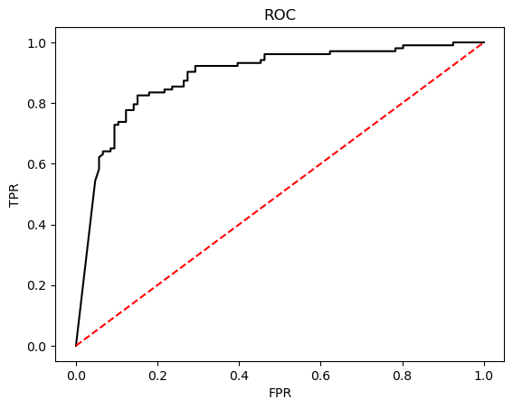

```
AUC score: 0.8881205348965013
```

```python
from sklearn.metrics import roc_curve, roc_auc_score

y_score = new_model.predict(X_test)
fpr, tpr, thresholds = roc_curve(y_test, y_score)
plt.plot(fpr, tpr, 'k')
plt.plot([0, 1], [0, 1], 'r--')
plt.xlabel('FPR')
plt.ylabel('TPR')
plt.title('ROC')
plt.show()
print('AUC score:', roc_auc_score(y_test, y_score))
```

### 3.2 Model Interpretation

#### Feature Importance

While neural networks account for feature importance within the network, we can perform an analysis of the features with a Random Forest Model.

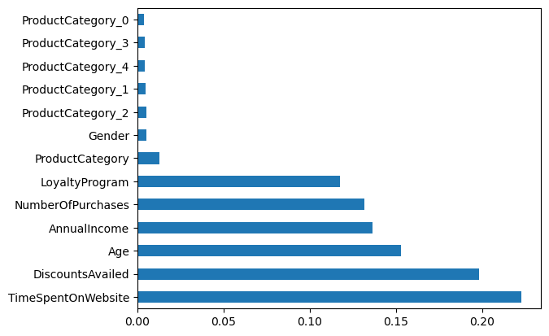

```python
from sklearn.ensemble import RandomForestClassifier

rfc = RandomForestClassifier(n_estimators=200, criterion='gini', max_depth=10,
                            min_samples_split=20, ccp_alpha=0.00, oob_score=True,
                            max_features='sqrt')
rfc.fit(X_train, y_train)

importances = rfc.feature_importances_
# std = np.std([RF.feature_importances_ for tree in RF.estimators_], axis=0)
idf = pd.DataFrame({'feature': X_train.columns, 'importance': importances})

idf = idf.sort_values('importance',ascending=False)
ax = idf.plot(kind='barh', x='feature', legend=False)
ax.set_ylabel('')
```

The variables that contributed the most to whether or not a customer would make a purchase are TimeSpentOnWebsite, DiscountsAvailed, and Age. It makes sense that time spent on the site has a high correlation with purchase status, since customers who spend longer on the site likely visited the site with a strong intention to make a purchase. However, this doesn't account for people who like to browse without buying, customers who leave the site page open for a long time, or visit the site for a short amount of time to purchase saved items. The number of discounts availed also contributes to the model's prediction, since discounts would strongly encourage customers to make a purchase. Age is a strong factor as well, since it indicates whether or not a customer is the target demographic of the online shop. On the lower end of feature importance, there is Gender and Product Category. This indicates that the shop likely has similar quality across all product categories, and does not cater towards a specific gender.

#### Confusion Matrix

```python
from sklearn.metrics import confusion_matrix, classification_report, f1_score

def get_report(y_test, y_pred):
    confmat =  pd.DataFrame(confusion_matrix(y_test, y_pred),
                      index=['True[0]','True[1]'],
                      columns=['Predict[0]', 'Predict[1]'])
    print(classification_report(y_test, y_pred))
    print('F1: %.3f' % f1_score(y_true=y_test, y_pred=y_pred))
    return confmat

y_score[y_score > 0.5] = 1
y_score[y_score <= 0.5] = 0
get_report(y_score, y_test)
```

```
              precision    recall  f1-score   support

         0.0       0.83      0.83      0.83       106
         1.0       0.83      0.83      0.83       103

    accuracy                           0.83       209
   macro avg       0.83      0.83      0.83       209
weighted avg       0.83      0.83      0.83       209

F1: 0.825
```

|  | Predict[0] | Predict[1] |
| --- | --- | --- |
| True[0] | 88 | 18 |
| True[1] | 18 | 85 |

The model is able to identify true positives and true negatives at a similar rate, due to the data having balanced cases for the target variable. In the context of e-commerce prediction, one implementation for this model can be used to identify customers who are projected to not make a purchase, and push advertisments or discount codes onto the customer during their site visit, increasing the likelihood of them buying something.

### 3.3 Conclusion

The model performed decently, showing improvement throughout stages of its development. The model could be further improved if there was more features in the dataset, such as site traffic (to distinguish active vs idle visitors), or more observations (since this dataset is relatively small for a training dataset for neural networks). Overall, I believe it can adequately serve as a tool for tracking customer behavior and allow the company to make data-driven marketing decisions.